# GI0

```r
library(GI0)
```

# Graphical Examples

Graphical examples to explore Generalized Inverse Gaussian (GI0) distribution using density plots, cumulative distribution function plots, and quantile function plots.

## 1.1. Density function

The density function of the GI0 distribution is used to compute the density values for different parameter settings of alpha, gamma, and the number of looks.

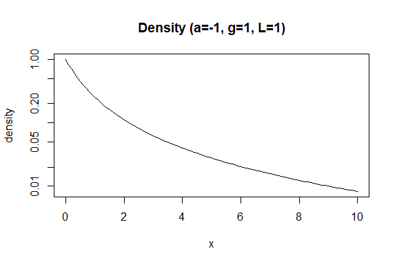

```r
# Example of density plots
# a=-1, g=1, L=1 semilogarithmic scale: it is not an exponential density
plot(function(x) dGI0(x, p_alpha=-1, p_gamma=1, p_Looks=1), from=0, to=10,
     log="y", type="l", xlab="x", ylab="density",
     main="Density (a=-1, g=1, L=1)")
```

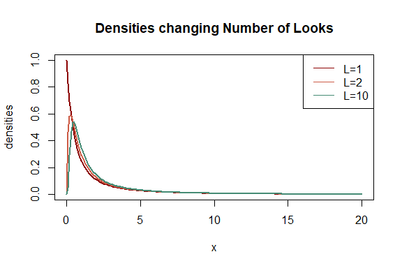

```r
# Checking the effect of changing the number of looks
x_vals <- seq(0, 20, length.out = 200)
density_L1 <- sapply(x_vals, function(x) dGI0(x, p_alpha = -1, p_gamma = 1, p_Looks = 1))
density_L2 <- sapply(x_vals, function(x) dGI0(x, p_alpha = -1, p_gamma = 1, p_Looks = 2))
density_L10 <- sapply(x_vals, function(x) dGI0(x, p_alpha = -1, p_gamma = 1, p_Looks = 10))

plot(x_vals, density_L1, type = "l", col = "darkred", xlab = "x", ylab = "densities",
     main = "Densities changing Number of Looks", lwd=2)
lines(x_vals, density_L2, col = "coral3", lwd=2)
lines(x_vals, density_L10, col = "aquamarine4", lwd=2)
legend("topright", legend = c("L=1", "L=2", "L=10"), col = c("darkred", "coral3", "aquamarine4"), lty = 1)
```

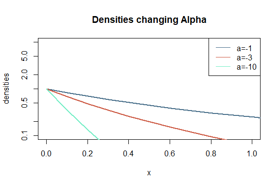

```r
# Checking effect of alpha

x <- seq(0, 10, length.out = 100)
plot(x, log="y", type="n",xlim=c(0,1), xlab="x", ylab="densities", main="Densities changing Alpha")
lines(x, dGI0(x, p_alpha=-1, p_gamma=1, p_Looks=1), col="skyblue4", lty=1,lwd=2)
lines(x, dGI0(x, p_alpha=-3, p_gamma=1, p_Looks=1), col="coral3", lty=1,lwd=2)
lines(x, dGI0(x, p_alpha=-10, p_gamma=1, p_Looks=1), col="aquamarine2", lty=1,lwd=2)
legend("topright", legend=c("a=-1", "a=-3", "a=-10"), col=c("skyblue4", "coral3", "aquamarine2"), lty=1)
```

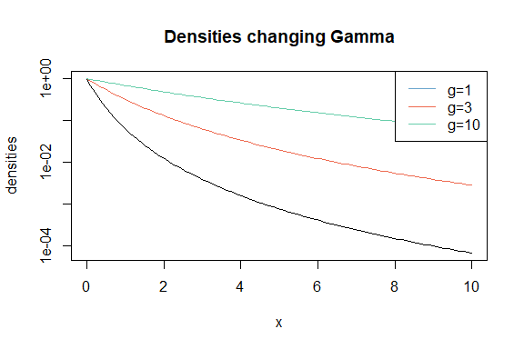

```r
# Checking the effect of changing gamma
plot(x, dGI0(x, p_alpha=-3, p_gamma=1, p_Looks=1),
     log="y", type="l", xlab="x", ylab="densities",
     main="Densities changing Gamma")
lines(x, dGI0(x, p_alpha=-3, p_gamma=3, p_Looks=1), col="coral2")
lines(x, dGI0(x, p_alpha=-3, p_gamma=10, p_Looks=1), col="aquamarine3")
legend("topright", legend=c("g=1", "g=3", "g=10"), col=c("skyblue3", "coral2", "aquamarine3"), lty=1)
```

## 1.2. Cumulative distribution function

The cumulative distribution function (CDF) is shown in the following plots with the effects of changing parameters.

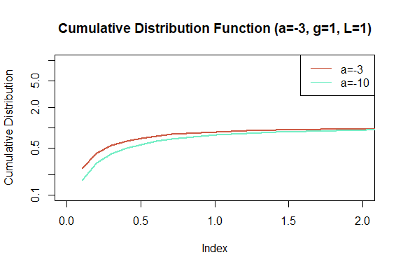

```r
# Checking log.p
x <- seq(0, 10, length.out = 100)
plot(x, log="y", type="n", xlim=c(0,2), ylab="Cumulative Distribution",
     main="Cumulative Distribution Function (a=-3, g=1, L=1)")
lines(x, pGI0(x, p_alpha=-3, p_gamma=1, p_Looks=1), col="coral3", lty=1,lwd=2)
lines(x, pGI0(x, p_alpha=-3, p_gamma=1, p_Looks=1, log.p=TRUE), col="aquamarine2", lty=1,lwd=2)
legend("topright", legend=c("a=-3", "a=-10"), col=c("coral3", "aquamarine2"), lty=1)
```

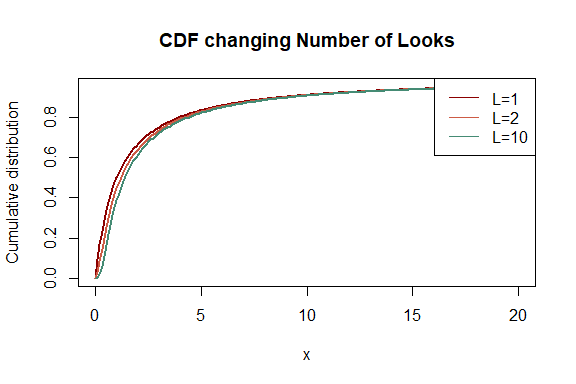

```r
# Checking number of looks
x_vals <- seq(0, 20, length.out = 200)
cdf_L1 <- sapply(x_vals, function(x) pGI0(x, p_alpha = -1, p_gamma = 1, p_Looks = 1))
cdf_L2 <- sapply(x_vals, function(x) pGI0(x, p_alpha = -1, p_gamma = 1, p_Looks = 2))
cdf_L10 <- sapply(x_vals, function(x) pGI0(x, p_alpha = -1, p_gamma = 1, p_Looks = 10))

plot(x_vals, cdf_L1, type = "l", col = "darkred", xlab = "x", ylab = "Cumulative distribution",
     main = "CDF changing Number of Looks", lwd=2)
lines(x_vals, cdf_L2, col = "coral3", lwd=2)
lines(x_vals, cdf_L10, col = "aquamarine4", lwd=2)
legend("topright", legend = c("L=1", "L=2", "L=10"), col = c("darkred", "coral3", "aquamarine4"), lty = 1)
```

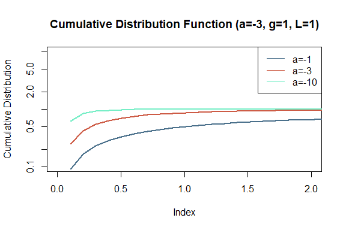

```r
# Checking alpha
x <- seq(0, 10, length.out = 100)
plot(x, log="y", type="n", xlim=c(0,2), ylab="Cumulative Distribution",
     main="Cumulative Distribution Function (a=-3, g=1, L=1)")
lines(x, pGI0(x, p_alpha=-1, p_gamma=1, p_Looks=1), col="skyblue4", lty=1,lwd=2)
lines(x, pGI0(x, p_alpha=-3, p_gamma=1, p_Looks=1), col="coral3", lty=1,lwd=2)
lines(x, pGI0(x, p_alpha=-10, p_gamma=1, p_Looks=1), col="aquamarine2", lty=1,lwd=2)
legend("topright", legend=c("a=-1", "a=-3", "a=-10"), col=c("skyblue4", "coral3", "aquamarine2"), lty=1)
```

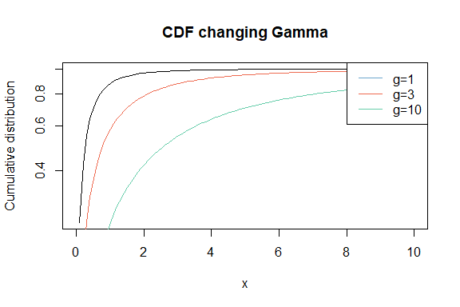

```r
# Checking gamma
plot(x, pGI0(x, p_alpha=-3, p_gamma=1, p_Looks=1),
     log="y", type="l", xlab="x", ylab="Cumulative distribution",
     main="CDF changing Gamma")
lines(x, pGI0(x, p_alpha=-3, p_gamma=3, p_Looks=1), col="coral2")
lines(x, pGI0(x, p_alpha=-3, p_gamma=10, p_Looks=1), col="aquamarine3")
legend("topright", legend=c("g=1", "g=3", "g=10"), col=c("skyblue3", "coral2", "aquamarine3"), lty=1)
```

## 1.3. Quantile function

The quantile function is visualized in the following plots with the following parameters changed.

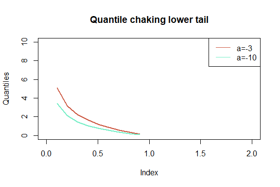

```r
# Checking lower.tail
x <- seq(0, 10, length.out = 100)
plot(x, type="n", xlim=c(0,2), ylab="Quantiles",
     main="Quantile chaking lower tail")

lines(x, qGI0(x, p_alpha=-3, p_gamma=1, p_Looks=1), col="coral3", lty=1,lwd=2)
lines(x, qGI0(x, p_alpha=-3, p_gamma=1, p_Looks=1, lower.tail=FALSE), col="aquamarine2", lty=1,lwd=2)
legend("topright", legend=c("a=-3", "a=-10"), col=c("coral3", "aquamarine2"), lty=1)
```

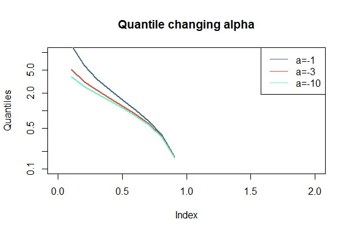

```r
# Checking alpha
x <- seq(0, 10, length.out = 100)
plot(x, log="y", type="n", xlim=c(0,2), ylab="Quantiles",
     main="Quantile changing alpha")
lines(x, qGI0(x, p_alpha=-1, p_gamma=1, p_Looks=1), col="skyblue4", lty=1,lwd=2)
lines(x, qGI0(x, p_alpha=-3, p_gamma=1, p_Looks=1), col="coral3", lty=1,lwd=2)
lines(x, qGI0(x, p_alpha=-10, p_gamma=1, p_Looks=1), col="aquamarine2", lty=1,lwd=2)
legend("topright", legend=c("a=-1", "a=-3", "a=-10"), col=c("skyblue4", "coral3", "aquamarine2"), lty=1)
```

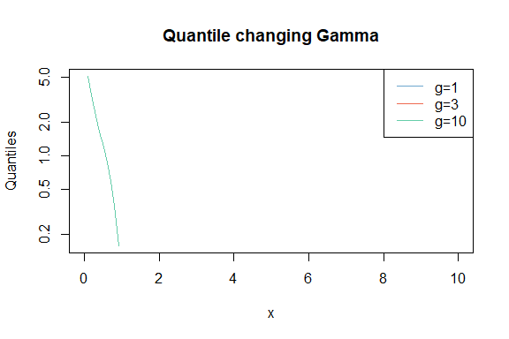

```r
# Checking gamma
plot(x, qGI0(x, p_alpha=-3, p_gamma=1, p_Looks=1),
     log="y", type="l", xlab="x", ylab="Quantiles",
     main="Quantile changing Gamma")
lines(x, qGI0(x, p_alpha=-3, p_gamma=3, p_Looks=1), col="coral2")
lines(x, qGI0(x, p_alpha=-3, p_gamma=10, p_Looks=1), col="aquamarine3")
legend("topright", legend=c("g=1", "g=3", "g=10"), col=c("skyblue3", "coral2", "aquamarine3"), lty=1)
```